# GEELY AUTO'S CAR MARKET ANALYSIS AND PRICE PREDICTION MODEL

INTRODUCTION A Chinese automobile company Geely Auto aspires to enter the Nigerian market by setting up its manufacturing unit and producing cars locally to compete with their Nigerian, US and European counterparts. GEELY AUTO wants to understand the factors on which the pricing of cars depends. Specifically, they want to understand the factors affecting the pricing of cars in the Nigerian market, since those may be very different from the Chinese market.

PROJECT OBJECTIVES

1. Model the price of cars with the available independent variables(i.e car price determinants). The management will use it to understand how exactly the prices vary with the independent variables. They can accordingly manipulate the design of the cars, the business strategy etc. to meet certain price levels.
2. The model will be a good way for management to understand the pricing dynamics of a new market.

```python
#IMPORTING LIBRARIES

import pandas as pd
import numpy as np
import matplotlib.pyplot as plt

%matplotlib inline
```

```python
Car = pd.read_csv("CarPrice_data.csv")
Car.head()
```

|  | car_ID | symboling | CarName | fueltype | aspiration | doornumber | carbody | drivewheel | enginelocation | wheelbase | ... | enginesize | fuelsystem | boreratio | stroke | compressionratio | horsepower | peakrpm | citympg | highwaympg | price |
| --- | --- | --- | --- | --- | --- | --- | --- | --- | --- | --- | --- | --- | --- | --- | --- | --- | --- | --- | --- | --- | --- |
| 0 | 1 | 3 | alfa-romero giulia | gas | std | two | convertible | rwd | front | 88.6 | ... | 130 | mpfi | 3.47 | 2.68 | 9.0 | 111 | 5000 | 21 | 27 | 13495.0 |
| 1 | 2 | 3 | alfa-romero stelvio | gas | std | two | convertible | rwd | front | 88.6 | ... | 130 | mpfi | 3.47 | 2.68 | 9.0 | 111 | 5000 | 21 | 27 | 16500.0 |
| 2 | 3 | 1 | alfa-romero Quadrifoglio | gas | std | two | hatchback | rwd | front | 94.5 | ... | 152 | mpfi | 2.68 | 3.47 | 9.0 | 154 | 5000 | 19 | 26 | 16500.0 |
| 3 | 4 | 2 | audi 100 ls | gas | std | four | sedan | fwd | front | 99.8 | ... | 109 | mpfi | 3.19 | 3.40 | 10.0 | 102 | 5500 | 24 | 30 | 13950.0 |
| 4 | 5 | 2 | audi 100ls | gas | std | four | sedan | 4wd | front | 99.4 | ... | 136 | mpfi | 3.19 | 3.40 | 8.0 | 115 | 5500 | 18 | 22 | 17450.0 |

5 rows × 26 columns

```python
Car.info()
```

```
<class 'pandas.core.frame.DataFrame'>
RangeIndex: 205 entries, 0 to 204
Data columns (total 26 columns):
 #   Column            Non-Null Count  Dtype
---  ------            --------------  -----
 0   car_ID            205 non-null    int64
 1   symboling         205 non-null    int64
 2   CarName           205 non-null    object
 3   fueltype          205 non-null    object
 4   aspiration        205 non-null    object
 5   doornumber        205 non-null    object
 6   carbody           205 non-null    object
 7   drivewheel        205 non-null    object
 8   enginelocation    205 non-null    object
 9   wheelbase         205 non-null    float64
```

[output cut: 18 more lines]

```python
#Statistical description of dataset.
round(Car.describe(),2)
```

|  | car_ID | symboling | wheelbase | carlength | carwidth | carheight | curbweight | enginesize | boreratio | stroke | compressionratio | horsepower | peakrpm | citympg | highwaympg | price |
| --- | --- | --- | --- | --- | --- | --- | --- | --- | --- | --- | --- | --- | --- | --- | --- | --- |
| count | 205.00 | 205.00 | 205.00 | 205.00 | 205.00 | 205.00 | 205.00 | 205.00 | 205.00 | 205.00 | 205.00 | 205.00 | 205.00 | 205.00 | 205.00 | 205.00 |
| mean | 103.00 | 0.83 | 98.76 | 174.05 | 65.91 | 53.72 | 2555.57 | 126.91 | 3.33 | 3.26 | 10.14 | 104.12 | 5125.12 | 25.22 | 30.75 | 13276.71 |
| std | 59.32 | 1.25 | 6.02 | 12.34 | 2.15 | 2.44 | 520.68 | 41.64 | 0.27 | 0.31 | 3.97 | 39.54 | 476.99 | 6.54 | 6.89 | 7988.85 |
| min | 1.00 | -2.00 | 86.60 | 141.10 | 60.30 | 47.80 | 1488.00 | 61.00 | 2.54 | 2.07 | 7.00 | 48.00 | 4150.00 | 13.00 | 16.00 | 5118.00 |
| 25% | 52.00 | 0.00 | 94.50 | 166.30 | 64.10 | 52.00 | 2145.00 | 97.00 | 3.15 | 3.11 | 8.60 | 70.00 | 4800.00 | 19.00 | 25.00 | 7788.00 |
| 50% | 103.00 | 1.00 | 97.00 | 173.20 | 65.50 | 54.10 | 2414.00 | 120.00 | 3.31 | 3.29 | 9.00 | 95.00 | 5200.00 | 24.00 | 30.00 | 10295.00 |
| 75% | 154.00 | 2.00 | 102.40 | 183.10 | 66.90 | 55.50 | 2935.00 | 141.00 | 3.58 | 3.41 | 9.40 | 116.00 | 5500.00 | 30.00 | 34.00 | 16503.00 |
| max | 205.00 | 3.00 | 120.90 | 208.10 | 72.30 | 59.80 | 4066.00 | 326.00 | 3.94 | 4.17 | 23.00 | 288.00 | 6600.00 | 49.00 | 54.00 | 45400.00 |

```python
#Checking for missing values.
Car.isnull().sum()
```

```
car_ID              0
symboling           0
CarName             0
fueltype            0
aspiration          0
doornumber          0
carbody             0
drivewheel          0
enginelocation      0
wheelbase           0
carlength           0
carwidth            0
carheight           0
curbweight          0
enginetype          0
cylindernumber      0
enginesize          0
fuelsystem          0
boreratio           0
stroke              0
compressionratio    0
horsepower          0
peakrpm             0
citympg             0
highwaympg          0
price               0
dtype: int64
```

# EXPLORATORY DATA ANALYSIS (EDA)

# UNIVARIATE ANALYSIS OF THE CAR PRICE VARIABLE DETERMINANTS

```python
Car[['CarName']]
```

|  | CarName |
| --- | --- |
| 0 | alfa-romero giulia |
| 1 | alfa-romero stelvio |
| 2 | alfa-romero Quadrifoglio |
| 3 | audi 100 ls |
| 4 | audi 100ls |
| ... | ... |
| 200 | volvo 145e (sw) |
| 201 | volvo 144ea |
| 202 | volvo 244dl |
| 203 | volvo 246 |
| 204 | volvo 264gl |

205 rows × 1 columns

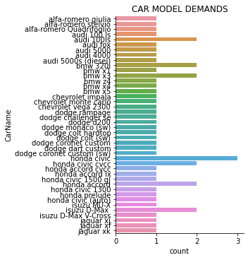

```python
import seaborn as sns

sns.catplot(data=Car.head(50), y='CarName', kind='count').set(title='CAR MODEL DEMANDS')
```

Above visualization shows that audi 100ls, bmw 320i,bmw x3,Isuzu D-Max are in popular demand in Nigeria car market making them a major competitors with Honda Civic leading the competitors.

```python
Car[['CarName', 'price']].head(40)
```

|  | CarName | price |
| --- | --- | --- |
| 0 | alfa-romero giulia | 13495.000 |
| 1 | alfa-romero stelvio | 16500.000 |
| 2 | alfa-romero Quadrifoglio | 16500.000 |
| 3 | audi 100 ls | 13950.000 |
| 4 | audi 100ls | 17450.000 |
| 5 | audi fox | 15250.000 |
| 6 | audi 100ls | 17710.000 |
| 7 | audi 5000 | 18920.000 |
| 8 | audi 4000 | 23875.000 |
| 9 | audi 5000s (diesel) | 17859.167 |
| 10 | bmw 320i | 16430.000 |
| 11 | bmw 320i | 16925.000 |
| 12 | bmw x1 | 20970.000 |
| 13 | bmw x3 | 21105.000 |
| 14 | bmw z4 | 24565.000 |
| 15 | bmw x4 | 30760.000 |
| 16 | bmw x5 | 41315.000 |
| 17 | bmw x3 | 36880.000 |
| 18 | chevrolet impala | 5151.000 |
| 19 | chevrolet monte carlo | 6295.000 |
| 20 | chevrolet vega 2300 | 6575.000 |
| 21 | dodge rampage | 5572.000 |
| 22 | dodge challenger se | 6377.000 |
| 23 | dodge d200 | 7957.000 |
| 24 | dodge monaco (sw) | 6229.000 |
| 25 | dodge colt hardtop | 6692.000 |
| 26 | dodge colt (sw) | 7609.000 |
| 27 | dodge coronet custom | 8558.000 |
| 28 | dodge dart custom | 8921.000 |
| 29 | dodge coronet custom (sw) | 12964.000 |
| 30 | honda civic | 6479.000 |
| 31 | honda civic cvcc | 6855.000 |
| 32 | honda civic | 5399.000 |
| 33 | honda accord cvcc | 6529.000 |
| 34 | honda civic cvcc | 7129.000 |
| 35 | honda accord lx | 7295.000 |
| 36 | honda civic 1500 gl | 7295.000 |
| 37 | honda accord | 7895.000 |
| 38 | honda civic 1300 | 9095.000 |
| 39 | honda prelude | 8845.000 |

```python
#Table showing car brand price in Nigeria
price = pd.pivot_table(data=Car,index='CarName',values='price', aggfunc=np.sum)
price
```

| CarName | price |
| --- | --- |
| Nissan versa | 5499.0 |
| alfa-romero Quadrifoglio | 16500.0 |
| alfa-romero giulia | 13495.0 |
| alfa-romero stelvio | 16500.0 |
| audi 100 ls | 13950.0 |
| ... | ... |
| volvo 246 | 22470.0 |
| volvo 264gl | 41045.0 |
| volvo diesel | 18950.0 |
| vw dasher | 11595.0 |
| vw rabbit | 9980.0 |

147 rows × 1 columns

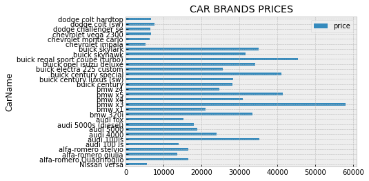

```python
#Plot to display the mostly priced car brands in Nigeria.
plt.style.use('bmh')
price.head(30).plot(kind='barh', title='CAR BRANDS PRICES')
```

```python
#Average car price in the market.

Car[['price']].mean()
```

```
price    13276.710571
dtype: float64
```

```python
#Minimum or least car price in the market.
Car[['price']].min()
```

```
price    5118.0
dtype: float64
```

```python
#Maximium car price in the market.

Car[['price']].max()
```

```
price    45400.0
dtype: float64
```

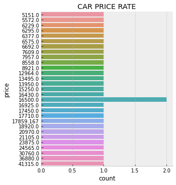

```python
sns.catplot(data=Car.head(30), y='price', kind='count').set(title='CAR PRICE RATE')
```

# MULTIVARIATE/BIVARIATE ANALYSIS OF THE CAR MARKET

```python
df = Car[['CarName','fueltype','doornumber','carbody']].head(30)
df
```

|  | CarName | fueltype | doornumber | carbody |
| --- | --- | --- | --- | --- |
| 0 | alfa-romero giulia | gas | two | convertible |
| 1 | alfa-romero stelvio | gas | two | convertible |
| 2 | alfa-romero Quadrifoglio | gas | two | hatchback |
| 3 | audi 100 ls | gas | four | sedan |
| 4 | audi 100ls | gas | four | sedan |
| 5 | audi fox | gas | two | sedan |
| 6 | audi 100ls | gas | four | sedan |
| 7 | audi 5000 | gas | four | wagon |
| 8 | audi 4000 | gas | four | sedan |
| 9 | audi 5000s (diesel) | gas | two | hatchback |
| 10 | bmw 320i | gas | two | sedan |
| 11 | bmw 320i | gas | four | sedan |
| 12 | bmw x1 | gas | two | sedan |
| 13 | bmw x3 | gas | four | sedan |
| 14 | bmw z4 | gas | four | sedan |
| 15 | bmw x4 | gas | four | sedan |
| 16 | bmw x5 | gas | two | sedan |
| 17 | bmw x3 | gas | four | sedan |
| 18 | chevrolet impala | gas | two | hatchback |
| 19 | chevrolet monte carlo | gas | two | hatchback |
| 20 | chevrolet vega 2300 | gas | four | sedan |
| 21 | dodge rampage | gas | two | hatchback |
| 22 | dodge challenger se | gas | two | hatchback |
| 23 | dodge d200 | gas | two | hatchback |
| 24 | dodge monaco (sw) | gas | four | hatchback |
| 25 | dodge colt hardtop | gas | four | sedan |
| 26 | dodge colt (sw) | gas | four | sedan |
| 27 | dodge coronet custom | gas | two | sedan |
| 28 | dodge dart custom | gas | four | wagon |
| 29 | dodge coronet custom (sw) | gas | two | hatchback |

```python
#Most used fuel type in the Nigerian car market.

Car[['fueltype']].value_counts()
```

```
fueltype
gas         185
diesel       20
dtype: int64
```

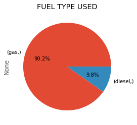

```python
plt.style.use('ggplot')

Car[['fueltype']].value_counts().plot(kind='pie', autopct='%1.1f%%',title='FUEL TYPE USED')
```

Plot above shows gas as the mostly used fueltype in Nigeria.

```python
Car[['carbody','doornumber']].value_counts()
```

```
carbody      doornumber
sedan        four          80
hatchback    two           60
wagon        four          25
sedan        two           16
hatchback    four          10
hardtop      two            8
convertible  two            6
dtype: int64
```

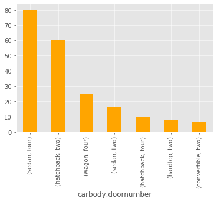

```python
#Plot showing body-type and door-numbers used in Nigeria.

Car[['carbody','doornumber']].value_counts().plot(kind='bar', color='orange')
```

The data and plot shows that Four doors sedan cars are higly dominant/sold and two doors hatchback come next to mostly demanded in the market with convertible cars in lowest demand in the Nigerian market.

```python
Eng = Car[['CarName','drivewheel','enginelocation','enginesize']]
Eng
```

|  | CarName | drivewheel | enginelocation | enginesize |
| --- | --- | --- | --- | --- |
| 0 | alfa-romero giulia | rwd | front | 130 |
| 1 | alfa-romero stelvio | rwd | front | 130 |
| 2 | alfa-romero Quadrifoglio | rwd | front | 152 |
| 3 | audi 100 ls | fwd | front | 109 |
| 4 | audi 100ls | 4wd | front | 136 |
| ... | ... | ... | ... | ... |
| 200 | volvo 145e (sw) | rwd | front | 141 |
| 201 | volvo 144ea | rwd | front | 141 |
| 202 | volvo 244dl | rwd | front | 173 |
| 203 | volvo 246 | rwd | front | 145 |
| 204 | volvo 264gl | rwd | front | 141 |

205 rows × 4 columns

```python
#Minimum engine size in Nigeria
Eng[['enginesize']].min()
```

```
enginesize    61
dtype: int64
```

```python
#Maximum engine size in Nigeria
Eng[['enginesize']].max()
```

```
enginesize    326
dtype: int64
```

```python
#The average engine size in Nigeria
Eng[['enginesize']].mean()
```

```
enginesize    126.907317
dtype: float64
```

```python
Car[['enginesize','drivewheel']].value_counts()
```

```
enginesize  drivewheel
122         fwd           15
97          fwd           14
92          fwd           13
110         fwd           12
90          fwd           12
98          fwd           10
109         fwd            8
141         rwd            7
146         rwd            6
108         fwd            6
121         fwd            6
152         rwd            6
108         4wd            5
91          fwd            5
```

[output cut: 40 more lines]

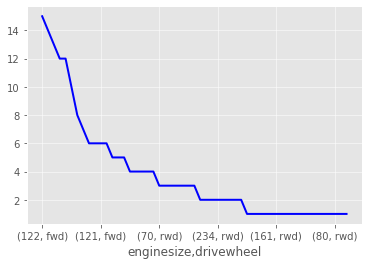

```python
Car[['enginesize','drivewheel']].value_counts().plot(kind='line',color='blue')
```

Car engine sizes of 122,97,92,110,90 and 98 on fwd are in high demand and popular in the Nigerian market contributing to price determinant.

```python
Car.loc[[13]]
```

|  | car_ID | symboling | CarName | fueltype | aspiration | doornumber | carbody | drivewheel | enginelocation | wheelbase | ... | enginesize | fuelsystem | boreratio | stroke | compressionratio | horsepower | peakrpm | citympg | highwaympg | price |
| --- | --- | --- | --- | --- | --- | --- | --- | --- | --- | --- | --- | --- | --- | --- | --- | --- | --- | --- | --- | --- | --- |
| 13 | 14 | 0 | bmw x3 | gas | std | four | sedan | rwd | front | 101.2 | ... | 164 | mpfi | 3.31 | 3.19 | 9.0 | 121 | 4250 | 21 | 28 | 21105.0 |

1 rows × 26 columns

# IDENTIFYING REGRESSION MODEL

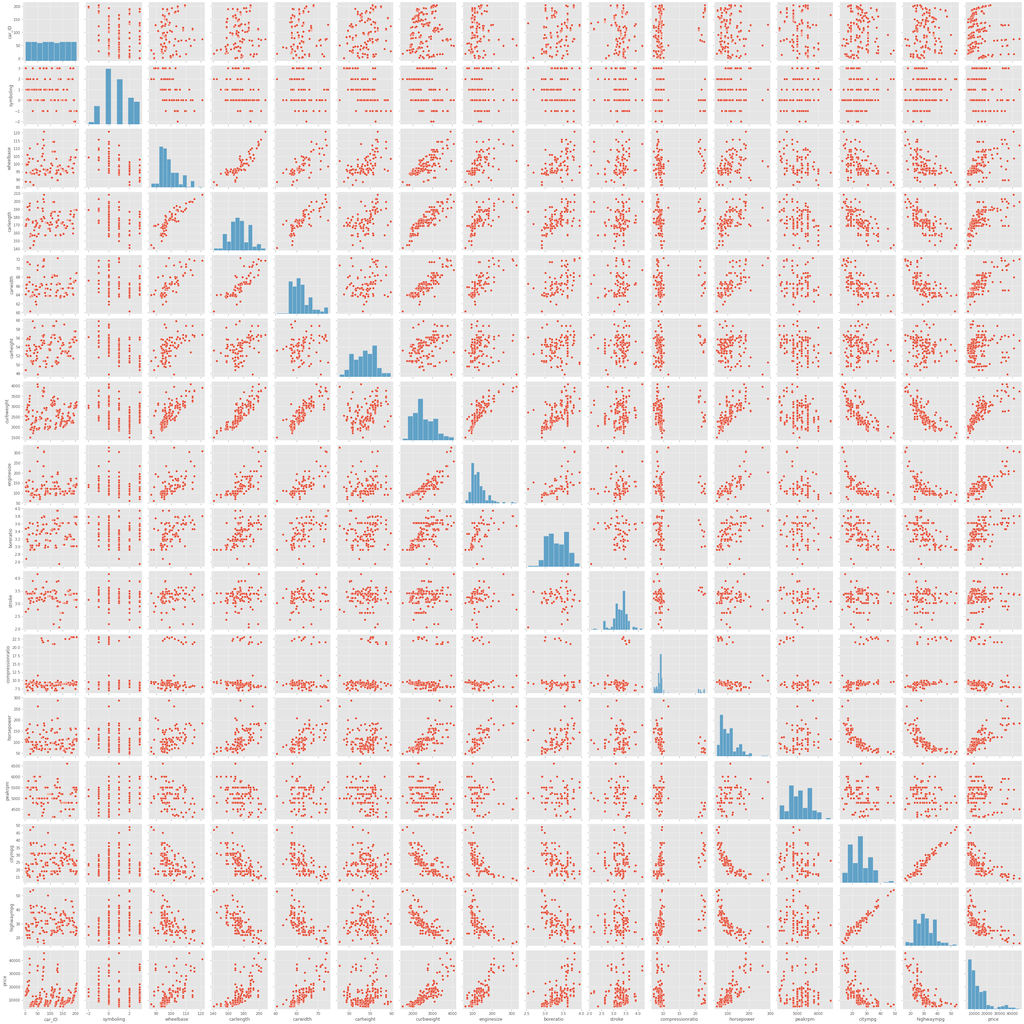

```python
#Pairplotting to identify related features and the regression.
sns.pairplot(Car)
```

```python
#Table showing the variables significant in car price prediction and how they correlate.


car_num = Car.corr()
car_num
```

|  | car_ID | symboling | wheelbase | carlength | carwidth | carheight | curbweight | enginesize | boreratio | stroke | compressionratio | horsepower | peakrpm | citympg | highwaympg | price |
| --- | --- | --- | --- | --- | --- | --- | --- | --- | --- | --- | --- | --- | --- | --- | --- | --- |
| car_ID | 1.000000 | -0.151621 | 0.129729 | 0.170636 | 0.052387 | 0.255960 | 0.071962 | -0.033930 | 0.260064 | -0.160824 | 0.150276 | -0.015006 | -0.203789 | 0.015940 | 0.011255 | -0.109093 |
| symboling | -0.151621 | 1.000000 | -0.531954 | -0.357612 | -0.232919 | -0.541038 | -0.227691 | -0.105790 | -0.130051 | -0.008735 | -0.178515 | 0.070873 | 0.273606 | -0.035823 | 0.034606 | -0.079978 |
| wheelbase | 0.129729 | -0.531954 | 1.000000 | 0.874587 | 0.795144 | 0.589435 | 0.776386 | 0.569329 | 0.488750 | 0.160959 | 0.249786 | 0.353294 | -0.360469 | -0.470414 | -0.544082 | 0.577816 |
| carlength | 0.170636 | -0.357612 | 0.874587 | 1.000000 | 0.841118 | 0.491029 | 0.877728 | 0.683360 | 0.606454 | 0.129533 | 0.158414 | 0.552623 | -0.287242 | -0.670909 | -0.704662 | 0.682920 |
| carwidth | 0.052387 | -0.232919 | 0.795144 | 0.841118 | 1.000000 | 0.279210 | 0.867032 | 0.735433 | 0.559150 | 0.182942 | 0.181129 | 0.640732 | -0.220012 | -0.642704 | -0.677218 | 0.759325 |
| carheight | 0.255960 | -0.541038 | 0.589435 | 0.491029 | 0.279210 | 1.000000 | 0.295572 | 0.067149 | 0.171071 | -0.055307 | 0.261214 | -0.108802 | -0.320411 | -0.048640 | -0.107358 | 0.119336 |
| curbweight | 0.071962 | -0.227691 | 0.776386 | 0.877728 | 0.867032 | 0.295572 | 1.000000 | 0.850594 | 0.648480 | 0.168790 | 0.151362 | 0.750739 | -0.266243 | -0.757414 | -0.797465 | 0.835305 |
| enginesize | -0.033930 | -0.105790 | 0.569329 | 0.683360 | 0.735433 | 0.067149 | 0.850594 | 1.000000 | 0.583774 | 0.203129 | 0.028971 | 0.809769 | -0.244660 | -0.653658 | -0.677470 | 0.874145 |
| boreratio | 0.260064 | -0.130051 | 0.488750 | 0.606454 | 0.559150 | 0.171071 | 0.648480 | 0.583774 | 1.000000 | -0.055909 | 0.005197 | 0.573677 | -0.254976 | -0.584532 | -0.587012 | 0.553173 |
| stroke | -0.160824 | -0.008735 | 0.160959 | 0.129533 | 0.182942 | -0.055307 | 0.168790 | 0.203129 | -0.055909 | 1.000000 | 0.186110 | 0.080940 | -0.067964 | -0.042145 | -0.043931 | 0.079443 |
| compressionratio | 0.150276 | -0.178515 | 0.249786 | 0.158414 | 0.181129 | 0.261214 | 0.151362 | 0.028971 | 0.005197 | 0.186110 | 1.000000 | -0.204326 | -0.435741 | 0.324701 | 0.265201 | 0.067984 |
| horsepower | -0.015006 | 0.070873 | 0.353294 | 0.552623 | 0.640732 | -0.108802 | 0.750739 | 0.809769 | 0.573677 | 0.080940 | -0.204326 | 1.000000 | 0.131073 | -0.801456 | -0.770544 | 0.808139 |
| peakrpm | -0.203789 | 0.273606 | -0.360469 | -0.287242 | -0.220012 | -0.320411 | -0.266243 | -0.244660 | -0.254976 | -0.067964 | -0.435741 | 0.131073 | 1.000000 | -0.113544 | -0.054275 | -0.085267 |
| citympg | 0.015940 | -0.035823 | -0.470414 | -0.670909 | -0.642704 | -0.048640 | -0.757414 | -0.653658 | -0.584532 | -0.042145 | 0.324701 | -0.801456 | -0.113544 | 1.000000 | 0.971337 | -0.685751 |
| highwaympg | 0.011255 | 0.034606 | -0.544082 | -0.704662 | -0.677218 | -0.107358 | -0.797465 | -0.677470 | -0.587012 | -0.043931 | 0.265201 | -0.770544 | -0.054275 | 0.971337 | 1.000000 | -0.697599 |
| price | -0.109093 | -0.079978 | 0.577816 | 0.682920 | 0.759325 | 0.119336 | 0.835305 | 0.874145 | 0.553173 | 0.079443 | 0.067984 | 0.808139 | -0.085267 | -0.685751 | -0.697599 | 1.000000 |

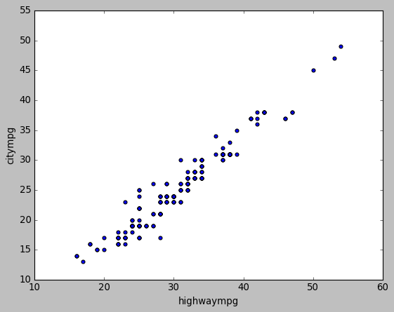

```python
plt.style.use('classic')
Car.plot.scatter(x='highwaympg',y='citympg')
```

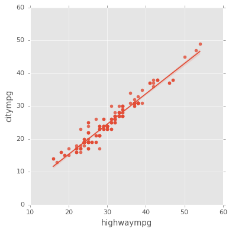

```python
#plot to identify the linear regression in the data.
plt.style.use('ggplot')
sns.lmplot(x='highwaympg',y='citympg',data=Car)
```

```
[Text(0.5, 1.0, 'PRICE DISTIBUTION')]
```

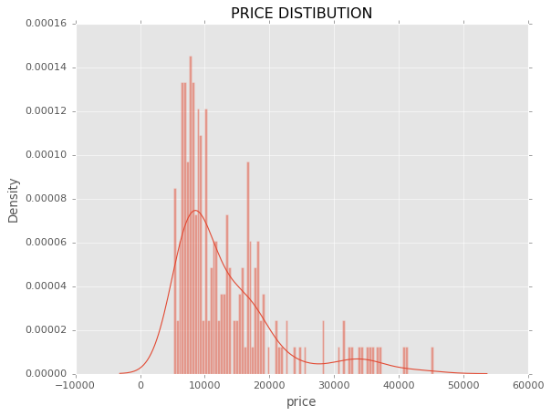

```python
import warnings
warnings.filterwarnings('ignore')

sns.distplot(Car['price'],bins=100, hist_kws={'alpha':0.5}).set(title='PRICE DISTIBUTION')
```

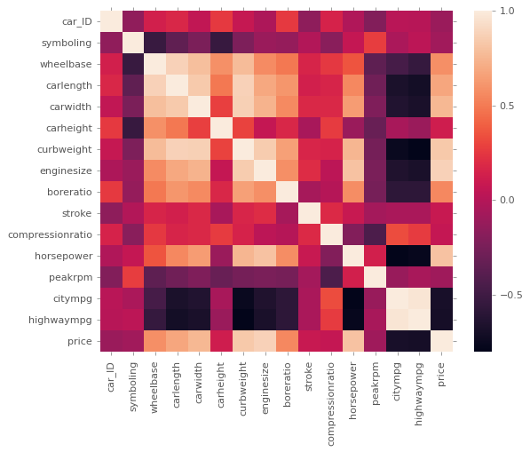

```python
#Heatmap showing correlation of modelling features
sns.heatmap(car_num)
```

```python
#Strongest correlation with car price  #Important Features
important_feat = car_num
print(f'There are {len(important_feat)} strongly correlated features with car price:')
```

[output not shown]

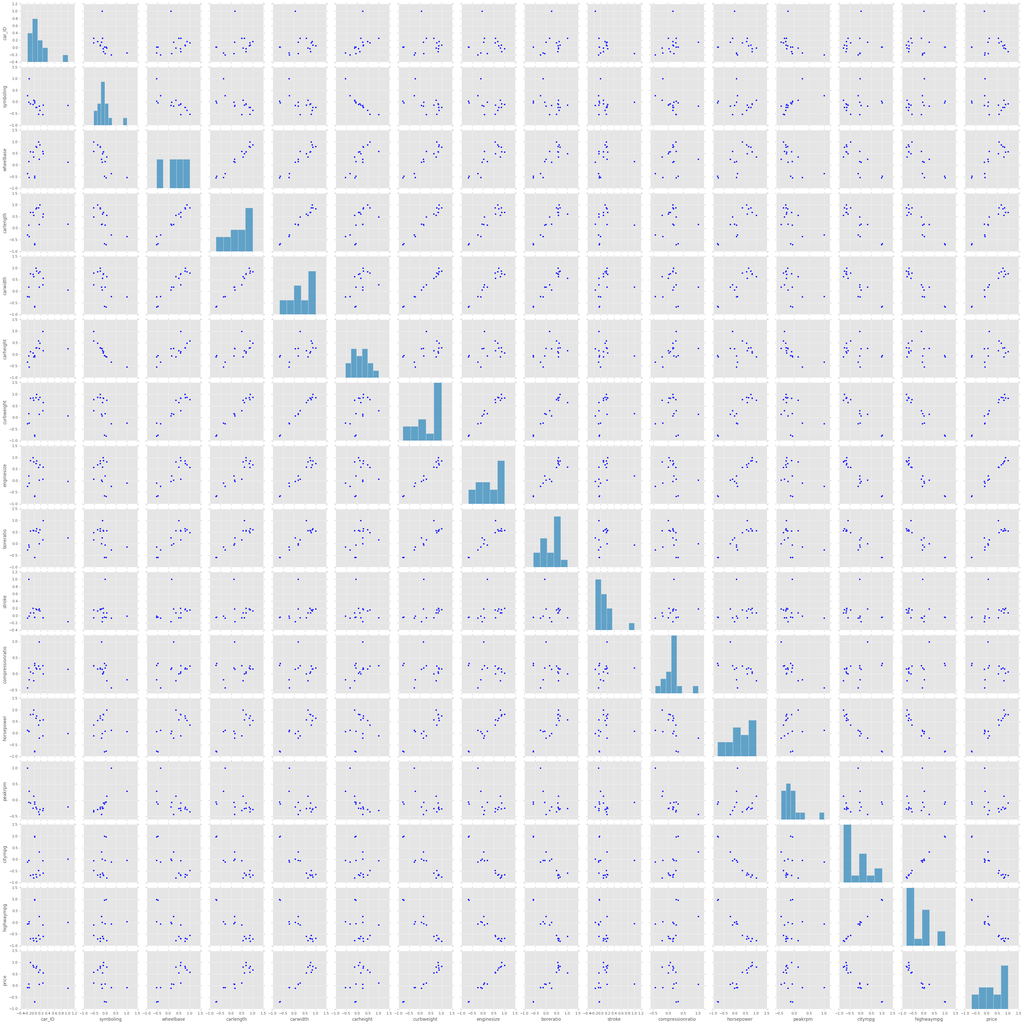

```python
sns.pairplot(data=car_num)
```

# FEATURES ENGINEERING

```python
#Arrays with training features
```

```python
Car.columns
```

```
Index(['car_ID', 'symboling', 'CarName', 'fueltype', 'aspiration',
       'doornumber', 'carbody', 'drivewheel', 'enginelocation', 'wheelbase',
       'carlength', 'carwidth', 'carheight', 'curbweight', 'enginetype',
       'cylindernumber', 'enginesize', 'fuelsystem', 'boreratio', 'stroke',
       'compressionratio', 'horsepower', 'peakrpm', 'citympg', 'highwaympg',
       'price'],
      dtype='object')
```

```python
#Features modelling by splitting dataset into Input(x) and Output(y) variables
x = Car[['car_ID', 'symboling','wheelbase',
       'carlength', 'carwidth', 'carheight', 'curbweight',
        'enginesize', 'boreratio', 'stroke',
       'compressionratio', 'horsepower', 'peakrpm', 'citympg', 'highwaympg']]
```

```python
#Prediction variable
y = Car[['price']]
```

# Training and Testing The Features

```python
from sklearn.linear_model import LinearRegression
from sklearn.neural_network import MLPRegressor   #Multi Layer Perceptron /deep learning
from sklearn.ensemble import RandomForestRegressor


#Train test split
from sklearn.model_selection import train_test_split
```

# Instantiate Model

```python
lm = LinearRegression()    #default hyperparameters
modelNN = MLPRegressor()
modelRF = RandomForestRegressor()
```

```python
#Splitting dataset into training and testing
x_test,x_train,y_test,y_train = train_test_split(x,y, test_size=0.4, random_state=85)
```

# Testing Model

```python
x_test
```

|  | car_ID | symboling | wheelbase | carlength | carwidth | carheight | curbweight | enginesize | boreratio | stroke | compressionratio | horsepower | peakrpm | citympg | highwaympg |
| --- | --- | --- | --- | --- | --- | --- | --- | --- | --- | --- | --- | --- | --- | --- | --- |
| 171 | 172 | 2 | 98.4 | 176.2 | 65.6 | 52.0 | 2714 | 146 | 3.62 | 3.500 | 9.3 | 116 | 4800 | 24 | 30 |
| 56 | 57 | 3 | 95.3 | 169.0 | 65.7 | 49.6 | 2380 | 70 | 3.33 | 3.255 | 9.4 | 101 | 6000 | 17 | 23 |
| 65 | 66 | 0 | 104.9 | 175.0 | 66.1 | 54.4 | 2670 | 140 | 3.76 | 3.160 | 8.0 | 120 | 5000 | 19 | 27 |
| 129 | 130 | 1 | 98.4 | 175.7 | 72.3 | 50.5 | 3366 | 203 | 3.94 | 3.110 | 10.0 | 288 | 5750 | 17 | 28 |
| 120 | 121 | 1 | 93.7 | 157.3 | 63.8 | 50.6 | 1967 | 90 | 2.97 | 3.230 | 9.4 | 68 | 5500 | 31 | 38 |
| ... | ... | ... | ... | ... | ... | ... | ... | ... | ... | ... | ... | ... | ... | ... | ... |
| 51 | 52 | 1 | 93.1 | 159.1 | 64.2 | 54.1 | 1900 | 91 | 3.03 | 3.150 | 9.0 | 68 | 5000 | 31 | 38 |
| 196 | 197 | -2 | 104.3 | 188.8 | 67.2 | 56.2 | 2935 | 141 | 3.78 | 3.150 | 9.5 | 114 | 5400 | 24 | 28 |
| 141 | 142 | 0 | 97.2 | 172.0 | 65.4 | 52.5 | 2145 | 108 | 3.62 | 2.640 | 9.5 | 82 | 4800 | 32 | 37 |
| 160 | 161 | 0 | 95.7 | 166.3 | 64.4 | 53.0 | 2094 | 98 | 3.19 | 3.030 | 9.0 | 70 | 4800 | 38 | 47 |
| 106 | 107 | 1 | 99.2 | 178.5 | 67.9 | 49.7 | 3139 | 181 | 3.43 | 3.270 | 9.0 | 160 | 5200 | 19 | 25 |

123 rows × 15 columns

```python
y_test
```

|  | price |
| --- | --- |
| 171 | 11549.0 |
| 56 | 11845.0 |
| 65 | 18280.0 |
| 129 | 31400.5 |
| 120 | 6229.0 |
| ... | ... |
| 51 | 6095.0 |
| 196 | 15985.0 |
| 141 | 7126.0 |
| 160 | 7738.0 |
| 106 | 18399.0 |

123 rows × 1 columns

# Training the Model

```python
lm.fit(x_train, y_train)
modelNN.fit(x_train, y_train)
modelRF.fit(x_train, y_train)


#cross validation
```

```
RandomForestRegressor()
```

```python
#Rsquared score
#measuring error in prediction and comparing models with each other based on their
#generalizability

from sklearn.metrics import r2_score
```

```python
lm.coef_
```

```
array([[-1.64696941e+01,  2.82337968e+02,  1.48431000e+02,
        -1.27952371e+02,  5.82611363e+02,  5.26035510e+02,
         6.43047697e-01,  1.20411939e+02,  3.05618005e+02,
        -2.90830134e+03,  4.33136321e+02,  3.72565521e+01,
         3.06025081e+00, -5.37568442e+02,  3.45436240e+02]])
```

```python
print(lm.score(x_test,y_test))
print(modelNN.score(x_test,y_test))
print(modelRF.score(x_test,y_test))
```

```
0.8117493270438878
0.17803654453745266
0.9200818784345529
```

# Import Sklearn Metrics

```python
from sklearn.metrics import mean_squared_error, r2_score, mean_absolute_error
```

```python
LRpred = lm.predict(x_test)
NNpred = modelNN.predict(x_test)
RFpred = modelRF.predict(x_test)
```